# Validation of 18-Protein Signature in APGI Cohort

### Introduction

Validation of the 18-protein Lasso-Cox prognostic signature (derived from CPTAC-PDAC) using the independent APGI/ProCan cohort.

**Methodology:** 1. Load APGI protein matrix (Gene Symbols). 2. Z-score normalize the APGI data (gene-wise) to match CPTAC processing. 3. Apply CPTAC Lasso coefficients to calculate Risk Score. 4. Perform Survival Analysis.

### Load Data

```r
# Paths
apgi_prot_path <- "/Users/galebabu-ali/Documents/CPTAC-PDA/Data/APGI-PDA/APGI_protein_matrix_gene_symbols.csv"
apgi_clin_path <- "/Users/galebabu-ali/Documents/CPTAC-PDA/Data/APGI-PDA/APGI_clinical_metadata.csv"
sig_path <- "/Users/galebabu-ali/Documents/CPTAC-PDA/Results/MOFA_Factor2_Protein_LassoSignature_18Proteins.csv"

# Load Data
apgi_prot <- read.csv(apgi_prot_path, row.names = 1, check.names = FALSE)
apgi_clin <- read.csv(apgi_clin_path, row.names = 1)
sig_df <- read.csv(sig_path)

cat("APGI Protein Matrix:", dim(apgi_prot)[1], "samples x", dim(apgi_prot)[2], "proteins\n")
```

```
## APGI Protein Matrix: 176 samples x 5599 proteins
```

```r
cat("Signature Proteins:", nrow(sig_df), "\n")
```

```
## Signature Proteins: 18
```

### Data Preprocessing

**Crucial Step:** The APGI data is DIA-MS absolute intensity. It must be gene-wise Z-score normalized (centered and scaled) before applying the CPTAC coefficients.

```r
# 1. Intersect Proteins
# Ensure we only use proteins present in both the signature and the APGI dataset
sig_proteins <- sig_df$Protein
common_proteins <- intersect(colnames(apgi_prot), sig_proteins)

cat("Proteins found in APGI cohort:", length(common_proteins), "/", length(sig_proteins), "\n")
```

```
## Proteins found in APGI cohort: 16 / 18
```

```r
missing <- setdiff(sig_proteins, colnames(apgi_prot))
if(length(missing) > 0) {
  warning("Missing proteins: ", paste(missing, collapse = ", "))
}
# Subset APGI matrix to common proteins
X_apgi <- apgi_prot[, common_proteins]

# 2. Calculate missingness percentage per protein
cat("\nMissing values per protein:\n")
```

```
##
## Missing values per protein:
```

```r
na_counts <- colSums(is.na(X_apgi))
na_pct <- (na_counts / nrow(X_apgi)) * 100
na_summary <- data.frame(
  Protein = names(na_counts),
  Missing_Count = na_counts,
  Missing_Pct = round(na_pct, 1)
) %>% arrange(desc(Missing_Pct))

print(na_summary[na_summary$Missing_Count > 0, ])
```

```
##        Protein Missing_Count Missing_Pct
## CEBPB    CEBPB            99        56.2
## F3          F3            96        54.5
## HMGCS2  HMGCS2            81        46.0
## IFITM3  IFITM3            65        36.9
## ADH1C    ADH1C            61        34.7
## MRTO4    MRTO4            61        34.7
## KPNA2    KPNA2            54        30.7
## GNAO1    GNAO1            32        18.2
## PRKCB    PRKCB            22        12.5
## C1QC      C1QC            17         9.7
## TNC        TNC            11         6.2
## CBR1      CBR1             1         0.6
```

```r
# Identify proteins with >50% missing data
proteins_to_exclude <- na_summary %>%
  filter(Missing_Pct > 50) %>%
  pull(Protein)

if(length(proteins_to_exclude) > 0) {
  cat("\nExcluding proteins with >50% missing data:", paste(proteins_to_exclude, collapse=", "), "\n")
  X_apgi <- X_apgi[, !colnames(X_apgi) %in% proteins_to_exclude]

  # Update signature to exclude these proteins
  sig_df_filtered <- sig_df %>%
    filter(!Protein %in% proteins_to_exclude)
} else {
  sig_df_filtered <- sig_df
}
```

```
##
## Excluding proteins with >50% missing data: CEBPB, F3
```

```r
cat("Signature proteins after filtering:", nrow(sig_df_filtered), "\n")
```

```
## Signature proteins after filtering: 16
```

```r
cat("Total samples with any NA in remaining signature proteins:", sum(rowSums(is.na(X_apgi)) > 0), "\n\n")
```

```
## Total samples with any NA in remaining signature proteins: 140
```

```r
# 3. Impute remaining missing values (median imputation per protein)
for(col in colnames(X_apgi)) {
  if(any(is.na(X_apgi[, col]))) {
    na_count <- sum(is.na(X_apgi[, col]))
    median_val <- median(X_apgi[, col], na.rm = TRUE)
    X_apgi[is.na(X_apgi[, col]), col] <- median_val
    cat("Imputed", na_count, "NAs in", col, "with median =", round(median_val, 2), "\n")
  }
}
```

```
## Imputed 61 NAs in ADH1C with median = 4.42
## Imputed 17 NAs in C1QC with median = 6.62
## Imputed 22 NAs in PRKCB with median = 5.42
## Imputed 32 NAs in GNAO1 with median = 3.49
## Imputed 1 NAs in CBR1 with median = 6.7
## Imputed 11 NAs in TNC with median = 6.03
## Imputed 54 NAs in KPNA2 with median = 2.51
## Imputed 81 NAs in HMGCS2 with median = 4.25
## Imputed 65 NAs in IFITM3 with median = 1.4
## Imputed 61 NAs in MRTO4 with median = 2.05
```

```r
# 4. Z-score Normalization
# Scale() function centers (mean=0) and scales (sd=1) columns (genes)
X_apgi_scaled <- scale(X_apgi)
cat("\nPost-scaling check - any NAs?", any(is.na(X_apgi_scaled)), "\n")
```

```
##
## Post-scaling check - any NAs? FALSE
```

```r
# 5. Ensure signature and APGI matrix have same proteins in same order
# Get the intersection of proteins (already filtered for >50% missing)
final_proteins <- intersect(sig_df_filtered$Protein, colnames(X_apgi_scaled))

cat("\nFinal protein alignment:\n")
```

```
##
## Final protein alignment:
```

```r
cat("Proteins in both signature and APGI:", length(final_proteins), "\n")
```

```
## Proteins in both signature and APGI: 14
```

```r
# Subset and reorder APGI matrix
X_apgi_scaled <- X_apgi_scaled[, final_proteins]

# Subset and reorder signature
sig_df_filtered <- sig_df_filtered %>%
  filter(Protein %in% final_proteins) %>%
  arrange(match(Protein, final_proteins))

# Verify alignment
cat("APGI proteins:", paste(colnames(X_apgi_scaled)[1:5], collapse=", "), "...\n")
```

```
## APGI proteins: HMGCS2, ADH1C, TNC, MYH11, PRKCB ...
```

```r
cat("Signature proteins:", paste(sig_df_filtered$Protein[1:5], collapse=", "), "...\n")
```

```
## Signature proteins: HMGCS2, ADH1C, TNC, MYH11, PRKCB ...
```

```r
cat("Order matches:", all(colnames(X_apgi_scaled) == sig_df_filtered$Protein), "\n")
```

```
## Order matches: TRUE
```

### Calculate Risk Score

$$RiskScore = \sum (Coefficient_i \times
Expression_i)$$

```r
# Verify one more time before calculation
if(!all(sig_df_filtered$Protein == colnames(X_apgi_scaled))) {
  stop("Protein alignment mismatch!")
}

# Extract coefficients (already aligned with X_apgi_scaled)
coeffs <- sig_df_filtered$Coefficient

# Calculate Risk Score
# Matrix multiplication: (Samples x Proteins) * (Proteins x 1)
risk_scores <- as.matrix(X_apgi_scaled) %*% coeffs
risk_scores <- as.vector(risk_scores)

# Create a dataframe for analysis
analysis_df <- data.frame(
  Case_ID = rownames(X_apgi_scaled),
  RiskScore = risk_scores,
  row.names = rownames(X_apgi_scaled)
)

# Debug: Check sample IDs before merge
cat("\nDEBUG INFO:\n")
```

```
##
## DEBUG INFO:
```

```r
cat("analysis_df rows:", nrow(analysis_df), "\n")
```

```
## analysis_df rows: 176
```

```r
cat("apgi_clin rows:", nrow(apgi_clin), "\n")
```

```
## apgi_clin rows: 176
```

```r
cat("First 5 analysis_df rownames:", paste(head(rownames(analysis_df)), collapse=", "), "\n")
```

```
## First 5 analysis_df rownames: 1699_Tumour, 3644_Normal, 3535_Tumour, 2215_Tumour, 3115_Normal, 2312_Tumour
```

```r
cat("First 5 apgi_clin rownames:", paste(head(rownames(apgi_clin)), collapse=", "), "\n")
```

```
## First 5 apgi_clin rownames: 1699_Tumour, 3644_Normal, 3535_Tumour, 2215_Tumour, 3115_Normal, 2312_Tumour
```

```r
# Merge with Clinical Data using rownames
analysis_df <- merge(analysis_df, apgi_clin, by = "row.names", all.x = TRUE)
rownames(analysis_df) <- analysis_df$Row.names
analysis_df$Row.names <- NULL

cat("After merge, analysis_df rows:", nrow(analysis_df), "\n")
```

```
## After merge, analysis_df rows: 176
```

```r
cat("Columns:", paste(colnames(analysis_df), collapse=", "), "\n\n")
```

```
## Columns: Case_ID, RiskScore, Prep_LIMS_ID, Acq_Type, Replicate, Amt.loaded, File_QC_check, Original_code_patient_id, X2D.matrix.Box.Coordinate, Filename_sample_info, Box.Number, Barocycler, Barocycler_processing, Barocycler_Date, RapidT_batch, Prep_date_RapidT, RapidT_Dil_buffer_batch, SPE_proces…
```

```r
# Define Risk Groups (25th and 75th percentiles)
q25 <- quantile(analysis_df$RiskScore, 0.25, na.rm = TRUE)
q75 <- quantile(analysis_df$RiskScore, 0.75, na.rm = TRUE)

# Create three groups: Low (bottom 25%), Intermediate (middle 50%), High (top 25%)
analysis_df$RiskGroup <- cut(analysis_df$RiskScore,
                              breaks = c(-Inf, q25, q75, Inf),
                              labels = c("Low Risk", "Intermediate", "High Risk"))

cat("\nRisk Group Distribution:\n")
```

```
##
## Risk Group Distribution:
```

```r
print(table(analysis_df$RiskGroup, useNA = "always"))
```

```
##
##     Low Risk Intermediate    High Risk         <NA>
##           44           88           44            0
```

```r
cat("\n25th percentile:", round(q25, 3), "\n")
```

```
##
## 25th percentile: -0.321
```

```r
cat("75th percentile:", round(q75, 3), "\n")
```

```
## 75th percentile: 0.311
```

### Survival Analysis

```r
# Define Survival Columns
time_col <- "Length.of.Follow.up..days."
event_col <- "OS"

# First, check if columns exist and inspect them
cat("Column exists?", event_col %in% colnames(analysis_df), "\n")
```

```
## Column exists? TRUE
```

```r
cat("OS column class:", class(analysis_df$OS), "\n")
```

```
## OS column class: character
```

```r
cat("OS column head:\n")
```

```
## OS column head:
```

```r
print(head(analysis_df$OS))
```

```
## [1] "Dead"  "Alive" "Alive" "Dead"  "Dead"  "Dead"
```

```r
cat("\nOS column unique values:\n")
```

```
##
## OS column unique values:
```

```r
print(table(analysis_df$OS, useNA = "always"))
```

```
##
## Alive  Dead  <NA>
##    28   148     0
```

```r
cat("\nUsing Time Column:", time_col, "\n")
```

```
##
## Using Time Column: Length.of.Follow.up..days.
```

```r
cat("Using Event Column:", event_col, "\n")
```

```
## Using Event Column: OS
```

```r
# Check for missing data before creating Surv object
cat("\nData Quality Check:\n")
```

```
##
## Data Quality Check:
```

```r
cat("Missing Time values:", sum(is.na(analysis_df[[time_col]])), "\n")
```

```
## Missing Time values: 0
```

```r
cat("Missing Event values:", sum(is.na(analysis_df[[event_col]])), "\n")
```

```
## Missing Event values: 0
```

```r
cat("Missing RiskScore values:", sum(is.na(analysis_df$RiskScore)), "\n")
```

```
## Missing RiskScore values: 0
```

```r
# Check unique values in event column
cat("\nUnique values in Event column:\n")
```

```
##
## Unique values in Event column:
```

```r
print(table(analysis_df[[event_col]], useNA = "always"))
```

```
##
## Alive  Dead  <NA>
##    28   148     0
```

```r
# Create Surv object
# Convert OS to binary (Dead=1, Alive=0)
event_binary <- ifelse(analysis_df[[event_col]] == "Dead", 1, 0)
cat("\nEvent binary distribution:\n")
```

```
##
## Event binary distribution:
```

```r
print(table(event_binary, useNA = "always"))
```

```
## event_binary
##    0    1 <NA>
##   28  148    0
```

```r
# Check time values
cat("\nTime column summary:\n")
```

```
##
## Time column summary:
```

```r
print(summary(as.numeric(analysis_df[[time_col]])))
```

```
##    Min. 1st Qu.  Median    Mean 3rd Qu.    Max.
##     6.0   311.0   543.5   891.4  1193.2  3513.0
```

```r
cat("Time values <= 0:", sum(as.numeric(analysis_df[[time_col]]) <= 0, na.rm = TRUE), "\n")
```

```
## Time values <= 0: 0
```

```r
# Remove rows with missing time, event, or RiskScore, AND time <= 0
valid_time <- !is.na(analysis_df[[time_col]]) & as.numeric(analysis_df[[time_col]]) > 0
valid_event <- !is.na(event_binary)
valid_risk <- !is.na(analysis_df$RiskScore)
complete_cases <- valid_time & valid_event & valid_risk

cat("\nComplete cases with valid time > 0:", sum(complete_cases), "of", nrow(analysis_df), "\n\n")
```

```
##
## Complete cases with valid time > 0: 176 of 176
```

```r
if(sum(complete_cases) == 0) {
  stop("No valid observations! Check time, event, and RiskScore columns.")
}

analysis_df_clean <- analysis_df[complete_cases, ]
event_binary_clean <- event_binary[complete_cases]

# Final check before creating Surv object
cat("Final data dimensions:\n")
```

```
## Final data dimensions:
```

```r
cat("Rows:", nrow(analysis_df_clean), "\n")
```

```
## Rows: 176
```

```r
cat("Events (deaths):", sum(event_binary_clean == 1), "\n")
```

```
## Events (deaths): 148
```

```r
cat("Censored:", sum(event_binary_clean == 0), "\n\n")
```

```
## Censored: 28
```

```r
y_surv <- Surv(time = as.numeric(analysis_df_clean[[time_col]]),
               event = event_binary_clean)

# 1. Cox Proportional Hazards Model
cox_fit <- coxph(y_surv ~ RiskScore, data = analysis_df_clean)
print(summary(cox_fit))
```

```
## Call:
## coxph(formula = y_surv ~ RiskScore, data = analysis_df_clean)
##
##   n= 176, number of events= 148
##
##             coef exp(coef) se(coef)     z Pr(>|z|)
## RiskScore 0.4463    1.5625   0.1531 2.915  0.00355 **
## ---
## Signif. codes:  0 '***' 0.001 '**' 0.01 '*' 0.05 '.' 0.1 ' ' 1
##
##           exp(coef) exp(-coef) lower .95 upper .95
## RiskScore     1.563       0.64     1.157     2.109
##
## Concordance= 0.601  (se = 0.024 )
## Likelihood ratio test= 8.57  on 1 df,   p=0.003
## Wald test            = 8.5  on 1 df,   p=0.004
## Score (logrank) test = 8.49  on 1 df,   p=0.004
```

```r
# Summarize Results
res <- summary(cox_fit)
cat(sprintf("\nValidation Results:\nHazard Ratio: %.2f (95%% CI: %.2f-%.2f), P = %.1e\n",
            res$conf.int[1], res$conf.int[3], res$conf.int[4], res$coefficients[5]))
```

```
##
## Validation Results:
## Hazard Ratio: 1.56 (95% CI: 1.16-2.11), P = 3.6e-03
```

```r
# 2. Kaplan-Meier Analysis - Comparing ONLY Top 25% vs Bottom 25%
# Filter to only Low Risk and High Risk groups (exclude Intermediate)
analysis_df_extremes <- analysis_df_clean %>%
  filter(RiskGroup %in% c("Low Risk", "High Risk"))

cat("\nExtreme Quartiles Analysis:\n")
```

```
##
## Extreme Quartiles Analysis:
```

```r
cat("Low Risk (bottom 25%):", sum(analysis_df_extremes$RiskGroup == "Low Risk"), "samples\n")
```

```
## Low Risk (bottom 25%): 44 samples
```

```r
cat("High Risk (top 25%):", sum(analysis_df_extremes$RiskGroup == "High Risk"), "samples\n")
```

```
## High Risk (top 25%): 44 samples
```

```r
# Create new Surv object for extreme quartiles only
event_extremes <- ifelse(analysis_df_extremes[[event_col]] == "Dead", 1, 0)
y_surv_extremes <- Surv(time = as.numeric(analysis_df_extremes[[time_col]]),
                        event = event_extremes)

# K-M fit for extreme quartiles
km_fit_extremes <- survfit(y_surv_extremes ~ RiskGroup, data = analysis_df_extremes)

# Check factor level order
cat("\nFactor levels of RiskGroup:\n")
```

```
##
## Factor levels of RiskGroup:
```

```r
print(levels(analysis_df_extremes$RiskGroup))
```

```
## [1] "Low Risk"     "Intermediate" "High Risk"
```

```
## Ignoring unknown labels:
## • colour : "Strata"
```

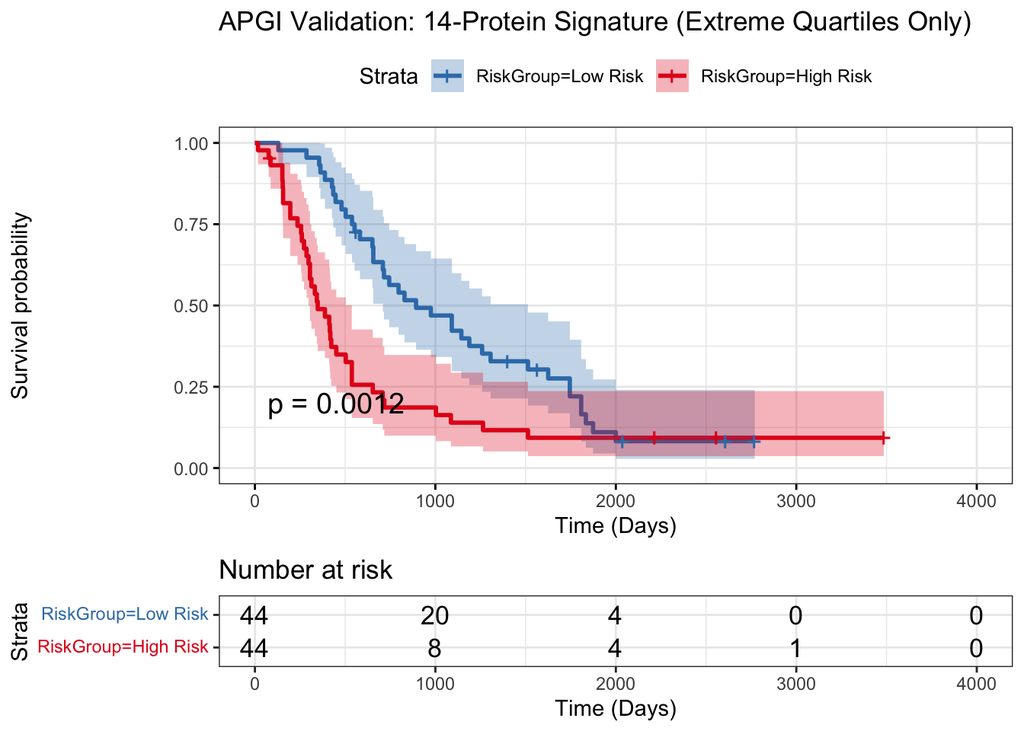

```r
# Plot
# Palette assigns colors based on factor levels order:
# If levels are c("High Risk", "Low Risk") -> first color is High Risk
# If levels are c("Low Risk", "High Risk") -> first color is Low Risk
ggsurvplot(km_fit_extremes,
           data = analysis_df_extremes,
           pval = TRUE,
           conf.int = TRUE,
           risk.table = TRUE,
           title = "APGI Validation: 14-Protein Signature (Extreme Quartiles Only)",
           xlab = "Time (Days)",
           palette = c("#377EB8", "#E41A1C"),  # Blue for Low Risk (first level), Red for High Risk (second level)
           ggtheme = theme_bw())
```

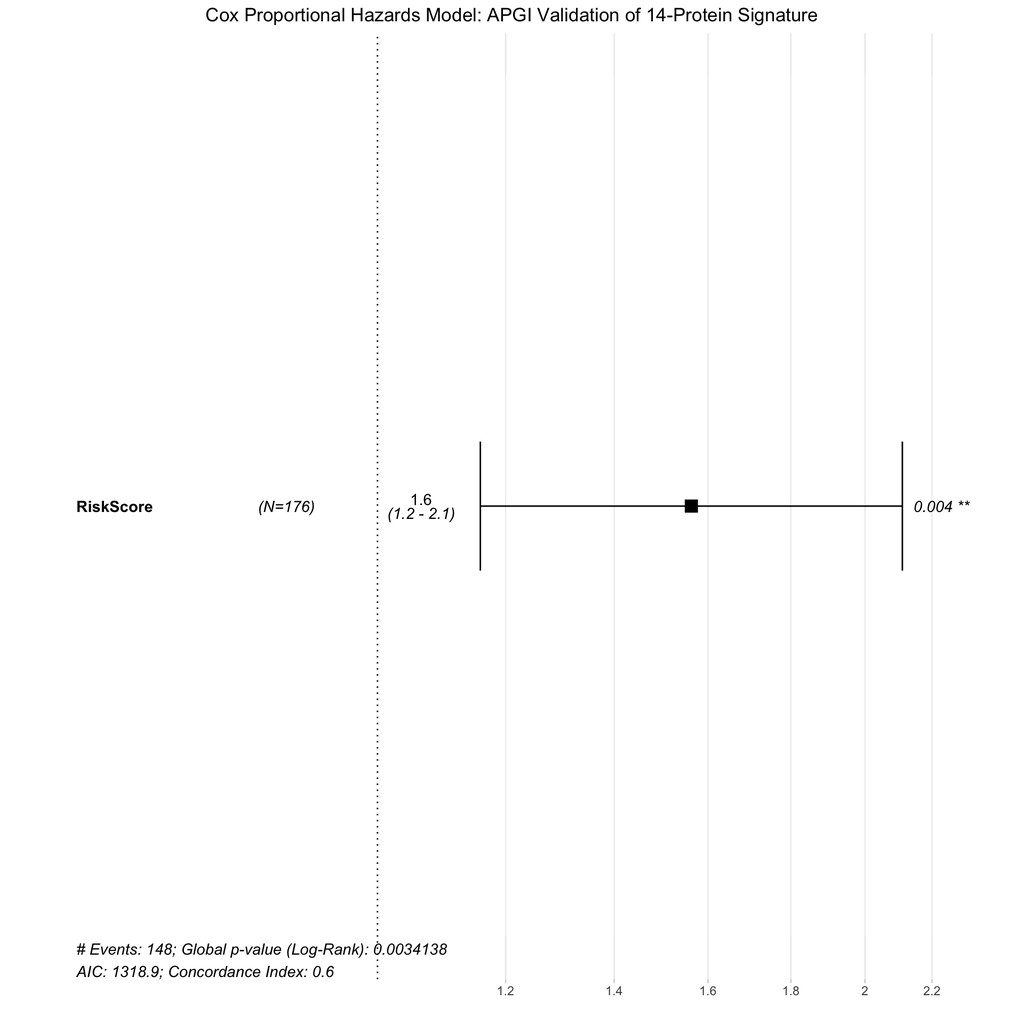

```r
# Forest plot for Cox model
ggforest(cox_fit,
         data = analysis_df_clean,
         main = "Cox Proportional Hazards Model: APGI Validation of 14-Protein Signature",
         cpositions = c(0.02, 0.22, 0.4),
         fontsize = 1.0)
```

## Results: External Validation in the APGI Cohort

To evaluate the clinical and technical robustness of the 18-protein Lasso-Cox model derived from the CPTAC-PDAC discovery cohort (Cao et al., 2021), external validation was performed using the independent Australian Pancreatic Cancer Genome Initiative (APGI) cohort (Aref et al., 2025; $n=176$). This cohort utilized Data-Independent Acquisition (DIA-MS), representing a significant technical shift from the TMT-labeling platform used in the discovery phase.

### Figure Legend: Validation of the 14-Protein Core Signature

Kaplan-Meier survival analysis and Cox regression performance in the independent APGI validation set ($n=176$; $148$ events). The Risk Score was calculated using the 14-protein core subset of the original 18-protein Lasso-Cox model.

**(B)** Continuous Cox proportional hazards model results ($HR = 1.56$, $p = 0.0036$), confirming the signature’s predictive value. Features with $>50\%$ missingness in the DIA-MS data were excluded to prevent imputation bias, underscoring the resilience of the biological signal across TMT and DIA platforms.

### References

**Discovery Study (CPTAC):**

Cao, L., Huang, C., Zhou, J. Y., et al. (2021). “Proteogenomic Characterization of Pancreatic Ductal Adenocarcinoma.” *Cell*, 184(19), 5031–5052. doi:10.1016/j.cell.2021.08.023.

**Validation Study (APGI):**

Aref, S., et al. (2025). “Mapping the Proteomic Landscape of Pancreatic Cancer to Profile Prognostic and Therapeutic Vulnerabilities.” *Cancer Research Communications*, 5(10), 1879–1892. doi:10.1158/2767-9764.CRC-24-0321.

**Methodological Reference (Lasso-Cox):**

Tibshirani, R. (1997). “The Lasso Method for Variable Selection in the Cox Model.” *Statistics in Medicine*, 16(4), 385–395.